# Project1Rao

umesh rao

2022-09-10

## Write one function that does steps 1 & 2 above. Give an optional argument (that is it has a defaultvalue) that allows the user to specify the name of the column representing the value (enrollment for these data sets).

There are 3 functions.1st will read the url, which is a csv file and returns a data frame, 2nd function will subset the data frame(from readfile function) for columns area_name, STcOU, all columns ending with “D”. It then pivots it longer, so i get area_name,STcou, Enrollement,value in the final data frame. The one function below will combine the above 2 functions and return the final dataset.It takes 2 arguments, the url and the variable nt whose default value is “Enrollment”. This is the function we will be using to call the other 2 functions

```r
library(tidyverse)
readfile<- function(url)
  {
    a<-  read_csv(url)
    return(a)
}
```

```r
selcol <- function(data,col1=Area_name,col2=STCOU,col3=D,nt=Enrollment,vt=value)
  {
    data %>%  select(col1,col2,ends_with("D")) %>% pivot_longer(cols = 3:12,names_to = nt,values_to = vt)
  }
```

```r
 func1<- function(url,nt="Enrollment")
   {
     a <- readfile(url)
     b <- selcol(a,"Area_name","STCOU","D",nt,"value")
     b<-  rename(b,c("area_name"="Area_name"))
   }
```

## Write another function that takes in the output of step 2 and does step 3 above.

This function takes the value of the column “enrollment” which is passed as an argument and converts it into a specific Characters for eg the value EDU01097 and converts it to EDU1997. This is done by using the substr function below.This function also adds a new variable year to the data frame

```r
question_3 <- function( y, data)
  {
    new_table <- data
    themin <- paste(substr((new_table[[y]]),1,3),as.numeric(substr((new_table[[y]]),8,9))+(1-round(as.numeric(substr((new_table[[y]]),8,9))/100))*2000 + round(as.numeric(substr((new_table[[y]]),8,9))/100)*1900,sep = "")
    new_table[[y]] <- themin
    new_table<- new_table %>% mutate (year=as.numeric(substr(Enrollment,4,7)))
    return(new_table)
  }
```

## Write a function to do step 5

```r
#Function to create a new variable state in the county dataset
cvr1 <- function(data1,data2)
  {
    data2<- separate(data1, col=area_name, into=c('area_name', 'state'), sep=',')
    data2$state <- trimws(data2$state, which = c("left"))
    data1<- data1 %>% select(area_name,STCOU,Enrollment,value,year)
    data2 <- (select(data2,state))
    bind_cols(data1,data2)
}
```

## Write a function to do step 6

This function will create a new variable called divsion by using the ifelse statement and assign a division value to specific states based on which division they belong to

```r
svr1 <- function(data)
 #Function to create division variable and assign values
  {
    data %>% mutate(division = ifelse(area_name %in% c("CONNECTICUT", "MAINE", "MASSACHUSETTS", "NEW HAMPSHIRE", "RHODE ISLAND", "VERMONT"), "DIVISION 1",ifelse(area_name %in% c("NEW JERSEY", "NEW YORK","PENNSYLVANIA"), "DIVISION 2",ifelse(area_name %in% c("ILLINOIS", "INDIANA"," MICHIGAN", "OHIO","WISCONSIN"), "DIVISION 3",ifelse(area_name %in% c("IOWA", "KANSAS","MINNESOTA", "MISSOURI", "NEBRASKA", "NORTH DAKOTA","SOUTH DAKOTA"), "DIVISION 4",ifelse(area_name %in% c("DELAWARE", "FLORIDA", "GEORGIA","MARYLAND","NORTH CAROLINA", "SOUTH CAROLINA", "VIRGINIA", "WASHINGTON, D.C","WEST VIRGINIA"), "DIVISION 5",ifelse(area_name %in% c("ALABAMA", "KENTUCKY", "MISSISSIPPI","TENNESSEE"), "DIVISION 6",ifelse(area_name %in% c("ARKANSAS", "LOUISIANA", "OKLAHOMA","TEXAS"), "DIVISION 7",ifelse(area_name %in% c("ARIZONA", "COLORADO", "IDAHO", "MONTANA", "NEVADA", "NEW MEXICO", "UTAH","WYOMING"), "DIVISION 8",ifelse(area_name %in% c("ALASKA", "CALIFORNIA", "HAWAII", "OREGON","WASHINGTON"), "DIVISION 9","ERROR"))))))))))
}
```

## Write another function that takes in the output from step 3 and creates the two tibbles in step 4, calls the above two functions (to perform steps 5 and 6), and returns two final tibbles.

This section defines 3 Function cnt will subset the data into a data frame which will have county values.stt will subset the data into a data frame which will have state values. The st456 function will take one argument as a data frame and use the cnnt, stt, cvr1,svr1 funtions and return a list of 2 data frames, one being county data and one being state data

```r
# Function to separate the main data set into county's
cnt <- function(data)
  {
    subset(data, area_name  %in%  grep(  ", \\w\\w",area_name,value=TRUE))
  }
# Function to separate the main data set into states
stt <- function(data)
  {
    subset(data, !(area_name  %in%  grep(  ", \\w\\w",area_name,value=TRUE)))
  }

#Main function to combine steps 4,5,6
#
st456 <- function(data1)
  {
    ef<-cnt(data1)
    ff<-stt(data1)
    hf<-cvr1(ef,ef1)
    class(hf) <- c("county", class(hf))
    gf<-svr1(ff)
    class(gf) <- c("state", class(gf))
    return(list(hf,gf))
  }
```

## Write wrapper function.

This wrapper function will take url and nt as variable and return a data frame which will be the final data frame we will be using to then return the two tibbles.

```r
my_wrapper <- function(url, nt = "Enrollment")
  {
    bf <- func1(url)
    cf = question_3("Enrollment", bf)
    v1<- st456(cf)
    return(v1)
  }
```

## Function to Combine Your Data

Using the function bind_rows to create on data set for county and state by reading 2 input files

```r
bindtb <- function(var1,var2)
  {
    bind_rows(var1,var2)
  }
```

## A function that plots the mean value of the statistic (enrollment for this data set) across the years for each Division.

This function will use ggploat to plot the x-year, y=avg(calculated statistics) for each division and use geom_line function which will draw a line of the points for each division (xy) values

```r
plot.state <- function(df, var_name = "avg")
  {
    new_df<-  df %>% group_by(division,year) %>% summarise(avg=mean(value))
    new_df<- subset(new_df, !division %in% c('ERROR'))
    ggplot(new_df, aes(x = year, y =avg, color = division)) + geom_line()
  }
```

##y.A function that allows the user to: - specify the state of interest, giving a default value if not specified - determine whether the ‘top’ or ‘bottom’ most counties should be looked at with a default for ‘top’ - instruct how many of the ‘top’ or ‘bottom’ will be investigated with a default value of 5 This function will use ggploat to plot the x-year, y=avg(calculated statistics) for each area_name and use geom_line function which will draw a line of the points for each area_name (xy) values

```r
plot.county <-function(data,st="PA",v1="top",v2=5)
  {
    new_cf <-data %>% filter(state==st)
    new_cf1<-new_cf %>% group_by(area_name) %>%  summarise(avg=mean(value))
    ifelse(v1=="top",new_cf1 <- arrange(new_cf1,desc(avg)),new_cf1 <- arrange(new_cf1,avg))
    new_cf2 <- head(new_cf1,v2)
    new_cf3 <-subset(new_cf,area_name %in% new_cf2$area_name)
    ggplot(new_cf3, aes(x = year, y = value, color = area_name)) +geom_line()
  }
```

# Putting all together

Ran the data processing function on the two enrollment URLs.Ran the data combining function to put these into one object.Used the plot function on the state data frame.Used the plot function on the county data frame

– Once without specifying anything (defaults used)

– Once specifying the state to be “MN”, the group being the top, the number looked at being 10

```r
output1 <-  my_wrapper("https://www4.stat.ncsu.edu/~online/datasets/EDU01a.csv")
```

[output not shown]

```r
state2 <- output1[[1]]
county2 <- output1[[2]]
output2 <-  my_wrapper("https://www4.stat.ncsu.edu/~online/datasets/EDU01b.csv")
```

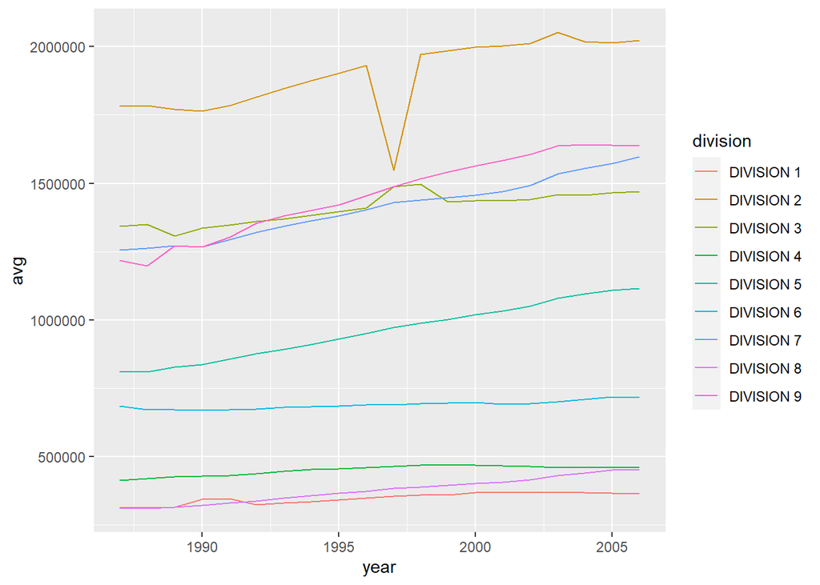

```r
state3 <- output2[[1]]
county3 <- output2[[2]]
cstate <-bindtb(state2,state3)
ccounty <-bindtb(county2,county3)
plot.state(ccounty,"avg")
```

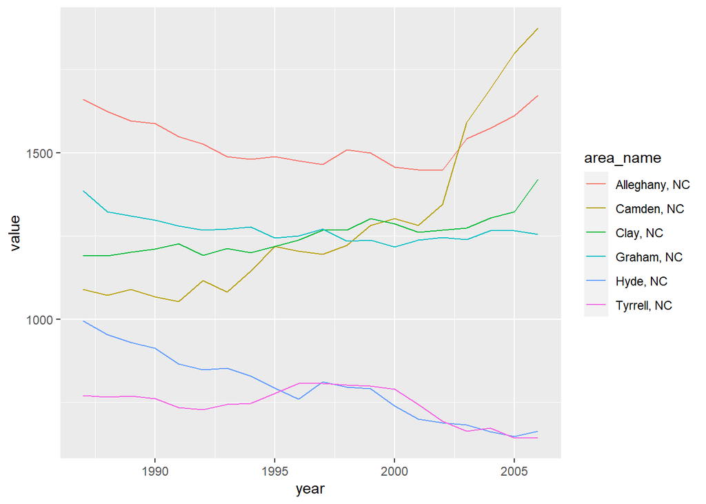

```r
plot.county(cstate,"NC","bottom",6)
```

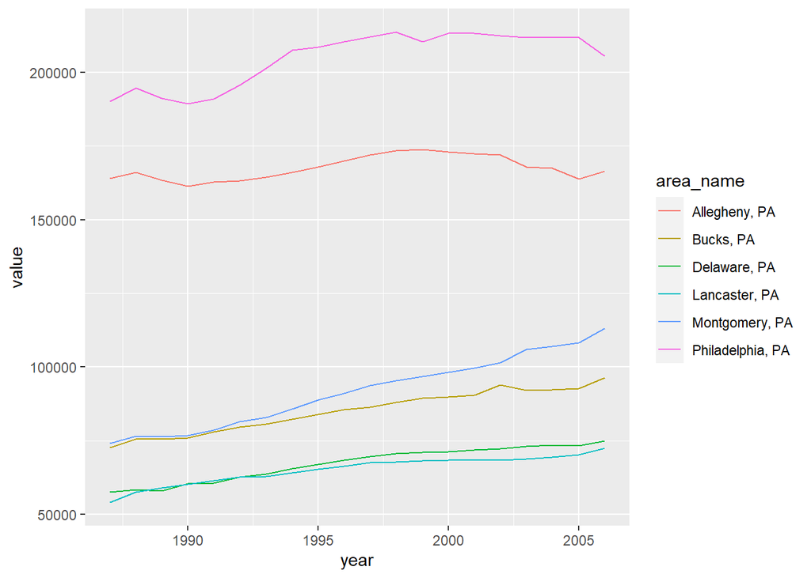

```r
# Use the plot function on the county data frame
plot.county(cstate,"PA","top",6)
```

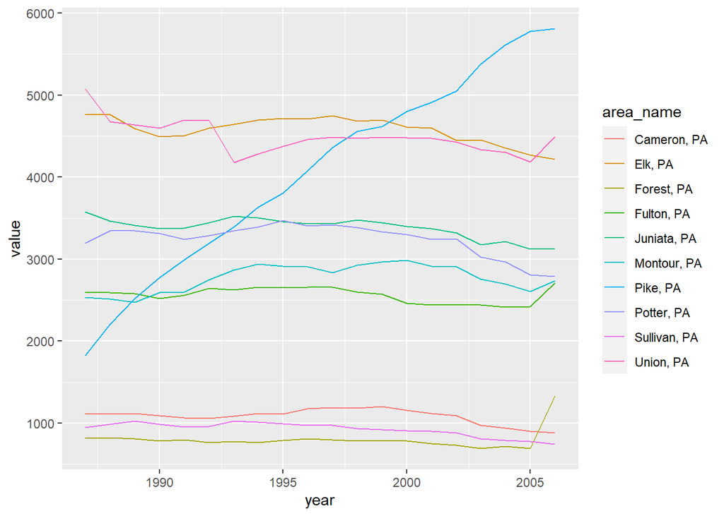

```r
plot.county(cstate,"PA","bottom",10)
```

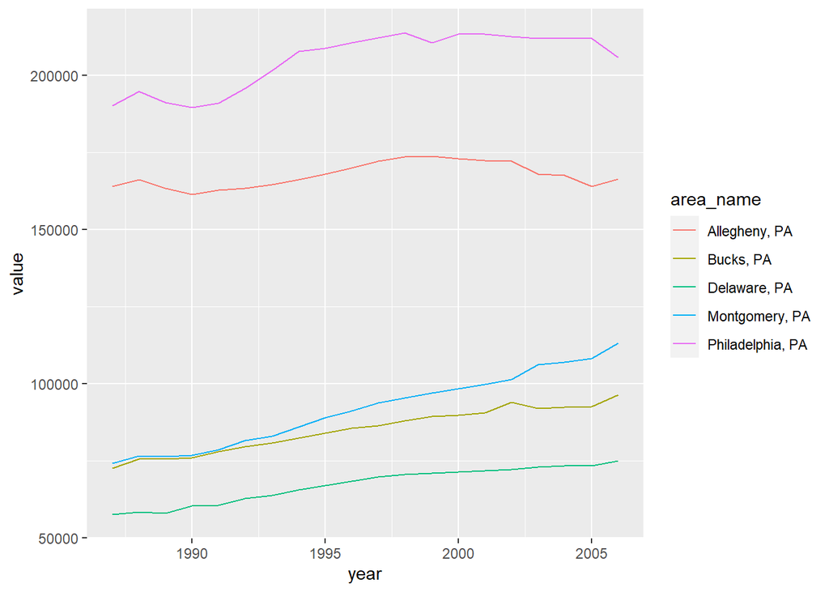

```r
plot.county(cstate)
```

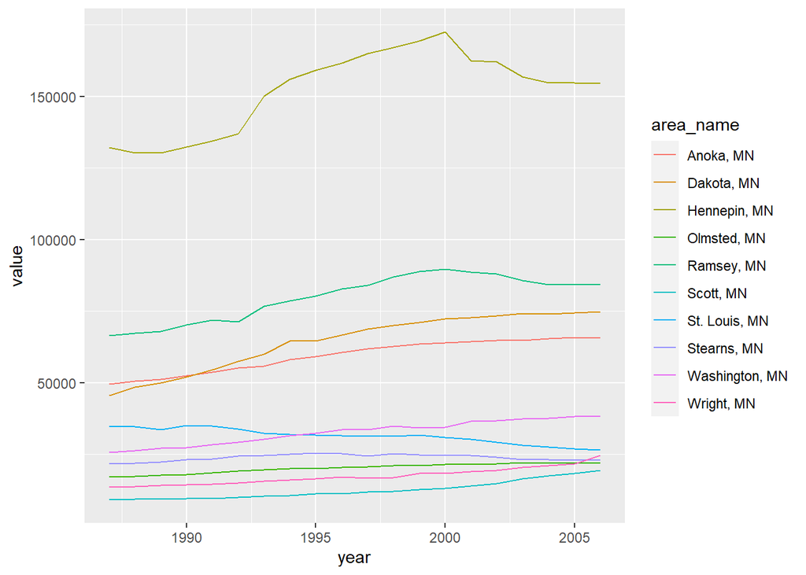

```r
plot.county(cstate,"MN","top",10)
```